# Exam I Review

We are going to do two review questions for the exam. If you can do these, you should be in good shape! For the review we will work with a built-in dataset called **economics**. It has six features:

**date** month of data collection **pce** personal consumption expenditures, in billions of dollars **pop** total population, in millions **psavert** personal savings rate (percentage) **uempmed** median duration of unemployment, in weeks **unemploy** number of unemployed in millions

Let’s look at the first few rows:

```r
economics
```

```
## # A tibble: 574 × 6
##    date         pce   pop psavert uempmed unemploy
##    <date>     <dbl> <dbl>   <dbl>   <dbl>    <dbl>
##  1 1967-07-01  507.  199.    12.6     4.5     2.94
##  2 1967-08-01  510.  199.    12.6     4.7     2.94
##  3 1967-09-01  516.  199.    11.9     4.6     2.96
##  4 1967-10-01  512.  199.    12.9     4.9     3.14
##  5 1967-11-01  517.  199.    12.8     4.7     3.07
##  6 1967-12-01  525.  200.    11.8     4.8     3.02
##  7 1968-01-01  531.  200.    11.7     5.1     2.88
##  8 1968-02-01  534.  200.    12.3     4.5     3.00
##  9 1968-03-01  544.  200.    11.7     4.1     2.88
## 10 1968-04-01  544   200.    12.3     4.6     2.71
## # … with 564 more rows
```

Notice that the first feature has a new data type (date). It has some special properties that we will look at in future classes. For now we can treat it like any other number.

## Review Question 1

Draw a line plot with date on the x-axis and the personal savings rate on the y-axis. Color the line in the color “grey75”. Add points in the color “#ff9393” showing the 24 months with the highest average savings rate:

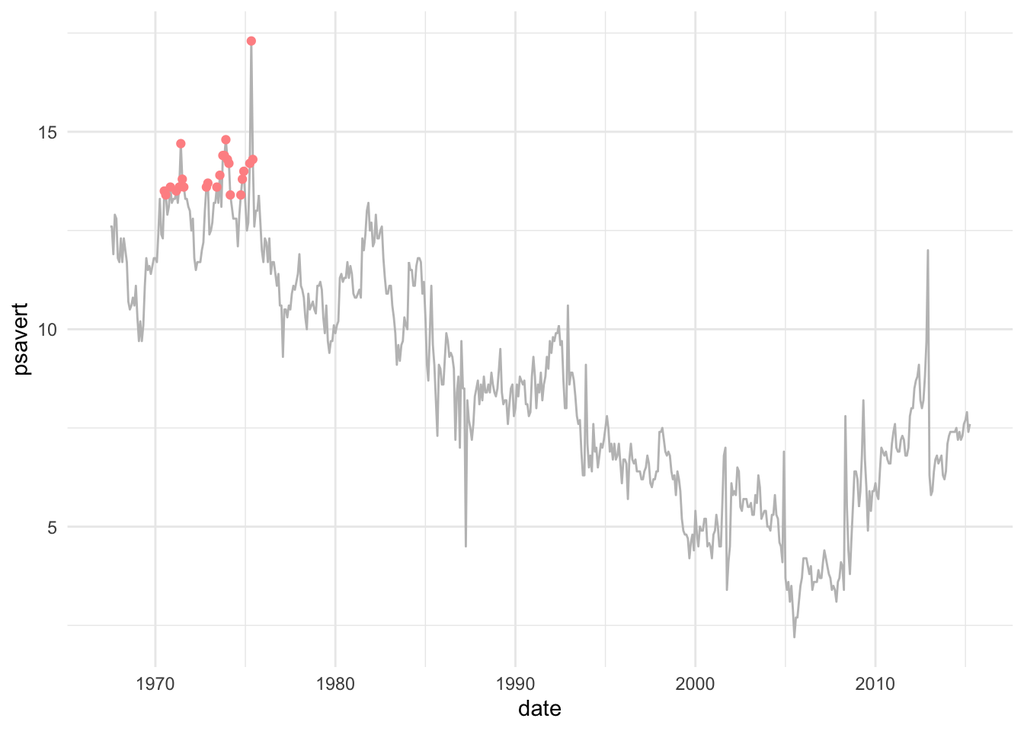

```r
hasr24 <- economics %>%
  arrange(desc(psavert)) %>%
  slice(1:24)

economics %>%
  ggplot() +
    geom_line(aes(x = date, y = psavert), color = "grey75") +
    geom_point(aes(x = date, y = psavert), color = "#ff9393", data = hasr24)
```

## Review Question 2

Draw a line plot with date on the x-axis that layers two lines: one giving the population on the y-axis and the other giving the number of unemployed workers on the y-axis. Color the population line in the color “#ff9393” and the unemployed line in the color “#999932”. Set the size aesthetic to both lines equal to 1.5 and make the y-axis scale logarithmic (base 10):

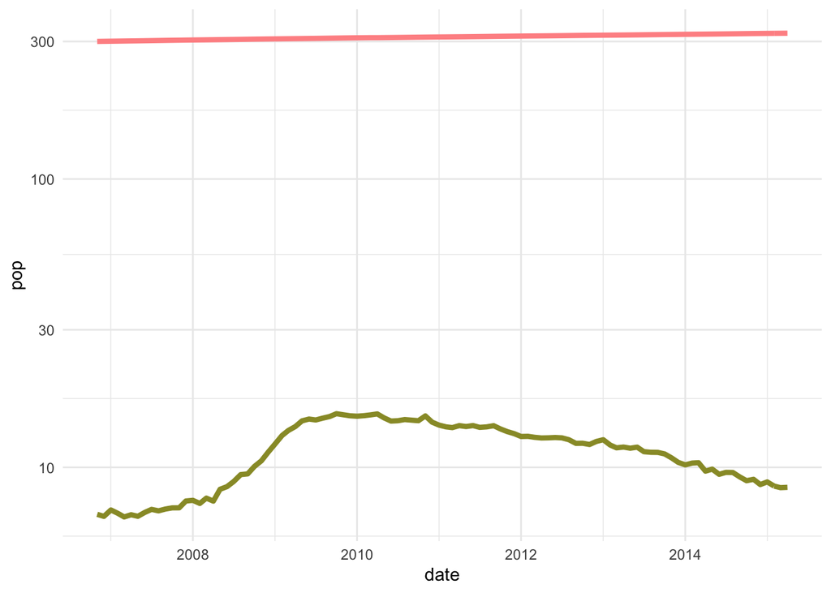

```r
economics %>%
  filter(pop > 300) %>%
  arrange(pop) %>%
  ggplot(aes(date, pop)) +
    geom_line(color = "#ff9393", size = 1.5) +
    geom_line(aes(y = unemploy), color = "#999932", size = 1.5) +
    scale_y_log10()
```